# Bibliography

Lennart Wittkuhn

Last update: 05 November, 2021

[figure not shown]

```r
path_bib <- here::here("public", "bibliography.csv")
bib <- data.table::fread(path_bib) %>%
  # turn URLs into hyperlinks that open in a new tap:
  .[, url := paste0("<a href='", url , "' target='_blank'>URL</a>")] %>%
  # remove curly brackets from the title:
  .[, title := gsub("[{}]", "", title)] %>%
  # convert dates when references were added:
  .[, ":="(date_added_converted = as.Date(
  get("date-added"), format = "%Y-%m-%d %H:%M:%S %z"))]
bib_all = bib %>%
  # select columns:
  .[,c("ID", "title", "author", "year", "journal", "url")]
```

# Overview

Welcome! This website showcases the bibliography maintained by Lennart Wittkuhn.

At the moment, this bibliography contains **1926 references** for publications in neuroscience, psychology, statistics, artificial intelligence, meta-science and more. The website was last updated on 05 November, 2021.

The source code of this website can be found at https://github.com/lnnrtwttkhn/bibliography/.

To understand how the bibliographical data was processed in this document, you can click on the `Code` tabs on the right. For example, by clicking on the first `Code` tab on the right, you will be able to see the R code that was used to load and process the bibliographical information stored in the `bibliography.bib` file.

# Usage

The table below lists all references sorted by the first author’s last name, publication year, and journal name (in that order).

You can use the `Search` bar on the right to search for certain publications (e.g., by author or journal name).

The `URL` column contains hyperlinks that should bring you to the publisher’s website for the corresponding publication.

When you use the `bibliography.bib` file in one of your documents (in LaTeX) and you want to cite one of the references, use the citation key in the `ID` column to cite the relevant publication, e.g., `\cite{Wittkuhn2020B}`.

If a reference is missing, please get in touch.

Figure 1 shows a table of the entire bibliography.

```r
DT::datatable(
  bib_all,
  class = "cell-border stripe", rownames = FALSE, escape = FALSE,
  options = list(
    scrollX = TRUE,
    pageLength = 5,
    lengthMenu = c(5, 10, 15, 20)
    ),
  )
```

| ID | title | author | year | journal | url |
| --- | --- | --- | --- | --- | --- |
| Abel2013CB | Sleep, Plasticity and Memory from Molecules to Whole-Brain Networks | Abel, Ted and Havekes, Robbert and Saletin, Jared M. and Walker, Matthew P. | 2013 | Current Biology | URL |
| Abraham2014FN | Machine learning for neuroimaging with scikit-learn | Abraham, Alexandre and Pedregosa, Fabian and Eickenberg, Michael and Gervais, Philippe and Mueller, Andreas and Kossaifi, Jean and Gramfort, Alexandre and Thirion, Bertrand and Varoquaux, Ga{\""e}l | 2014 | Frontiers in Neuroinformatics | URL |
| Abramowitz1964DPI | Handbook of Mathematical Functions with Formulas, Graphs, and Mathematical Tables | Abramowitz, Milton and Stegun, Irene A. | 1964 | Dover Publications, Inc. | URL |
| Acker2019JN | Stable memory and computation in randomly rewiring neural networks | Acker, Daniel and Paradis, Suzanne and Miller, Paul | 2019 | Journal of Neurophysiology | URL |
| Adam2012ITSCPAR | Experience Replay for Real-Time Reinforcement Learning Control | Adam, Sander and Busoniu, Lucian and Babuska, Robert | 2012 | IEEE Transactions on Systems, Man, and Cybernetics, Part C (Applications and Reviews) | URL |
| Adamantidis2019NRN | Oscillating circuitries in the sleeping brain | Adamantidis, Antoine R. and Gutierrez Herrera, Carolina and Gent, Thomas C. | 2019 | Nature Reviews Neuroscience | URL |
| Adcock2006N | Reward-Motivated Learning: Mesolimbic Activation Precedes Memory Formation | Adcock, R. Alison and Thangavel, Arul and Whitfield-Gabrieli, Susan and Knutson, Brian and Gabrieli, John D.E. | 2006 | Neuron | URL |
| Aggleton2007H | Structural learning and the hippocampus | Aggleton, John P. and Sanderson, David J. and Pearce, John M. | 2007 | Hippocampus | URL |
| Agrawal2020B | The Temporal Dynamics of Opportunity Costs: A Normative Account of Cognitive Fatigue and Boredom | Agrawal, Mayank and Mattar, Marcelo Gomes and Cohen, Jonathan D. and Daw, Nathaniel Douglass | 2020 | bioRxiv | URL |
| Aguirre1998N | The Variability of Human, BOLD Hemodynamic Responses | Aguirre, G.K. and Zarahn, E. and D'Esposito, M. | 1998 | NeuroImage | URL |

[output cut: 1916 more lines]

Figure 1: Table of all publications in `bibliography.bib`.

# Filter

In the sections below, I filter the bibliography e.g., depending on certain keywords.

## Replay

Table 2 list all publications in the `bibliography.bib` file that mention the term `replay` in the abstract or the title:

```r
search_terms = c("replay")
bib_replay = bib %>%
  .[, ":="(abstract_lower = tolower(abstract), title_lower = tolower(title))] %>%
  filter_at(
    .vars = vars(abstract_lower, title_lower),
    .vars_predicate = any_vars(
      stringr::str_detect(
        string = .,
        pattern = paste(search_terms, collapse = "|")))) %>%
  setDT(.) %>%
  .[, c("ID", "title", "author", "year", "journal", "url")] %>%
  setorder(author, year)
DT::datatable(
  bib_replay,
  class = "cell-border stripe", rownames = FALSE, escape = FALSE,
  options = list(
    scrollX = TRUE,
    pageLength = 5,
    lengthMenu = c(5, 10, 15, 20)
    ),
  )
```

| ID | title | author | year | journal | url |
| --- | --- | --- | --- | --- | --- |
| Abel2013CB | Sleep, Plasticity and Memory from Molecules to Whole-Brain Networks | Abel, Ted and Havekes, Robbert and Saletin, Jared M. and Walker, Matthew P. | 2013 | Current Biology | URL |
| Acker2019JN | Stable memory and computation in randomly rewiring neural networks | Acker, Daniel and Paradis, Suzanne and Miller, Paul | 2019 | Journal of Neurophysiology | URL |
| Adam2012ITSCPAR | Experience Replay for Real-Time Reinforcement Learning Control | Adam, Sander and Busoniu, Lucian and Babuska, Robert | 2012 | IEEE Transactions on Systems, Man, and Cybernetics, Part C (Applications and Reviews) | URL |
| Aljundi2019ANIPS | Gradient based sample selection for online continual learning | Aljundi, Rahaf and Lin, Min and Goujaud, Baptiste and Bengio, Yoshua | 2019 | Advances in Neural Information Processing Systems 32 | URL |
| Ambrose2016N | Reverse Replay of Hippocampal Place Cells Is Uniquely Modulated by Changing Reward | Ambrose, R. Ellen and Pfeiffer, Brad E. and Foster, David J. | 2016 | Neuron | URL |
| Ambrose2016JHU | Hippocampal Replay and Learning from Reward | Ambrose, Rebecca Ellen | 2016 | Johns Hopkins University | URL |
| Andrychowicz2017ANIPS | Hindsight Experience Replay | Andrychowicz, Marcin and Wolski, Filip and Ray, Alex and Schneider, Jonas and Fong, Rachel and Welinder, Peter and McGrew, Bob and Tobin, Josh and Abbeel, Pieter and Zaremba, Wojciech | 2017 | Advances in Neural Information Processing Systems | URL |
| Antonov2021B | Optimism and Pessimism in Optimised Replay | Antonov, Georgy and Gagne, Christopher and Eldar, Eran and Dayan, Peter | 2021 | bioRxiv | URL |
| Antony2019NRN | Active and effective replay: systems consolidation reconsidered again | Antony, James W. and Schapiro, Anna C. | 2019 | Nature Reviews Neuroscience | URL |
| Atherton2015TN | Memory trace replay: the shaping of memory consolidation by neuromodulation | Atherton, Laura A. and Dupret, David and Mellor, Jack R. | 2015 | Trends in Neurosciences | URL |

[output cut: 240 more lines]

Figure 2: Table listing studies mentioning ‘replay’ in the abstract.

Figure 3 shows the number of papers published per year, containing replay-related search terms in the abstract. Note, that the numbers are based only on the publications in the bibliography. The bibliography likely does not contain *all* publications on `replay` or `reactivation` in the literature.

```r
search_terms = c("replay", "reactivation")
bib_replay_time = bib %>%
  transform(abstract = tolower(abstract), title = tolower(title)) %>%
  # search for search terms in title and abstract
  filter_at(
    .vars = vars(abstract, title),
    .vars_predicate = any_vars(
      stringr::str_detect(
        string = .,
        pattern = paste(search_terms, collapse = "|")))) %>%
  setDT(.) %>%
  .[, by = .(year), .(N = .N)] %>%
  setorder(year) %>%
  transform(year = as.Date(ISOdate(year, 1, 1)))
```

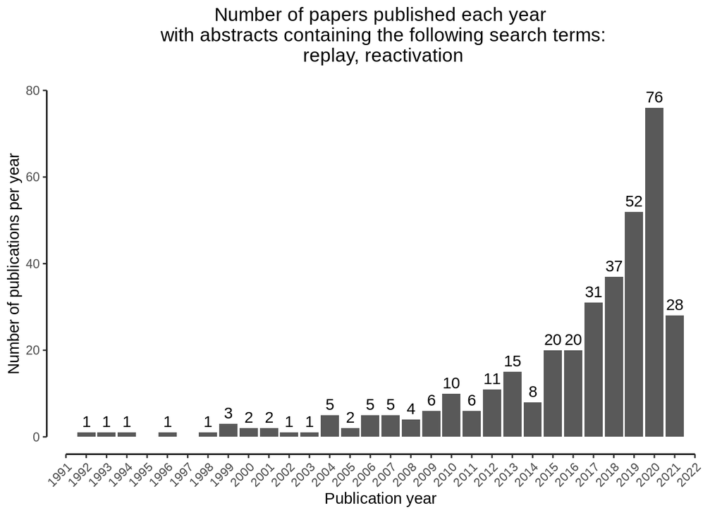

Figure 3: Number of papers published per year, containing replay-related search terms in the abstract

```r
title_string = paste("Number of papers published each year\n",
                     "with abstracts containing the following search terms:\n",
                     paste(search_terms, collapse = ", " ))
ggplot(data = bib_replay_time, aes(x = year, y = N)) +
  geom_bar(stat = "identity") +
  ggtitle(title_string) +
  ylab("Number of publications per year") +
  xlab("Publication year") +
  theme(panel.background = element_blank()) +
  theme(panel.grid.major = element_blank()) +
  theme(panel.grid.minor = element_blank()) +
  theme(axis.line = element_line(colour = "black")) +
  coord_capped_cart(bottom = "both", left = "both") +
  scale_x_date(date_breaks = "1 years", date_labels =  "%Y") +
  theme(axis.text.x = element_text(angle = 45, hjust = 1)) +
  theme(plot.title = element_text(hjust = 0.5)) +
  geom_text(aes(label = N), vjust = -0.5) +
  ylim(c(0, 80))
```

## Replay Literature Reviews

In this section, I filter publications in the `bibliography.bib` file for **literature review papers on replay**. The matching papers are listed in Figure 4, sorted by year in descending order (newest to oldest) and author name (alphabetical).

```r
bib_replay_review = bib %>%
  filter(stringr::str_detect(string = tags, pattern = "replay")) %>%
  filter(stringr::str_detect(string = tags, pattern = "review")) %>%
  setDT(.) %>%
  .[,c("ID", "title", "author", "year", "journal", "url")] %>%
  setorder(., -year, author)
DT::datatable(
  data = bib_replay_review,
  class = "cell-border stripe", rownames = FALSE, escape = FALSE,
  options = list(
    scrollX = TRUE,
    pageLength = 5,
    lengthMenu = c(5, 10, 15, 20)
  ),
)
```

| ID | title | author | year | journal | url |
| --- | --- | --- | --- | --- | --- |
| Findlay2021SA | The evolving view of replay and its functions in wake and sleep | Findlay, Graham and Tononi, Giulio and Cirelli, Chiara | 2021 | SLEEP Advances | URL |
| Roscow2021TN | Learning offline: memory replay in biological and artificial reinforcement learning | Roscow, Emma L. and Chua, Raymond and Costa, Rui Ponte and Jones, Matt W. and Lepora, Nathan | 2021 | Trends in Neurosciences | URL |
| Wittkuhn2021NBR | Replay in minds and machines | Wittkuhn, Lennart and Chien, Samson and Hall-McMaster, Sam and Schuck, Nicolas W. | 2021 | Neuroscience \& Biobehavioral Reviews | URL |
| Mobbs2020TCS | Space, Time, and Fear: Survival Computations along Defensive Circuits | Mobbs, Dean and Headley, Drew B. and Ding, Weilun and Dayan, Peter | 2020 | Trends in Cognitive Sciences | URL |
| Momennejad2020P | Learning Structures: Predictive Representations, Replay, and Generalization | Momennejad, Ida | 2020 | PsyArXiv | URL |
| Ruch2020TCS | Learning During Sleep: A Dream Comes True? | Ruch, Simon and Henke, Katharina | 2020 | Trends in Cognitive Sciences | URL |
| Zielinski2020H | The role of replay and theta sequences in mediating hippocampal-prefrontal interactions for memory and cognition | Zielinski, Mark C. and Tang, Wenbo and Jadhav, Shantanu P. | 2020 | Hippocampus | URL |
| Clewett2019H | Transcending time in the brain: How event memories are constructed from experience | Clewett, David and DuBrow, Sarah and Davachi, Lila | 2019 | Hippocampus | URL |
| Gruber2019TCS | How Curiosity Enhances Hippocampus-Dependent Memory: The Prediction, Appraisal, Curiosity, and Exploration (PACE) Framework | Gruber, Matthias J. and Ranganath, Charan | 2019 | Trends in Cognitive Sciences | URL |
| Klinzing2019NN | Mechanisms of systems memory consolidation during sleep | Klinzing, Jens G. and Niethard, Niels and Born, Jan | 2019 | Nature Neuroscience | URL |

[output cut: 48 more lines]

Figure 4: Table of literature reviews on replay.

## Intracranial recordings in humans

In this section, I filter publications in the `bibliography.bib` file for papers using **intracranial recordings in humans**. The matching papers are listed in Figure 5. Many (but not all!) of them are investigating replay-like signals in the medial temporal lobe and therefore establish important correspondence to electrophysiological recordings of replay in rodents.

```r
bib_intracranial = bib %>%
  filter(stringr::str_detect(string = tags, pattern = "human")) %>%
  filter(stringr::str_detect(string = tags, pattern = "intracranial")) %>%
  setDT(.) %>%
  .[,c("ID", "title", "author", "year", "journal", "url")]
DT::datatable(
  data = bib_intracranial,
  class = "cell-border stripe", rownames = FALSE, escape = FALSE,
  options = list(
    scrollX = TRUE,
    pageLength = 5,
    lengthMenu = c(5, 10, 15, 20)
  ),
)
```

| ID | title | author | year | journal | url |
| --- | --- | --- | --- | --- | --- |
| Axmacher2008B | Ripples in the medial temporal lobe are relevant for human memory consolidation | Axmacher, Nikolai and Elger, Christian E. and Fell, Juergen | 2008 | Brain | URL |
| Bower2015JN | Evidence for Consolidation of Neuronal Assemblies after Seizures in Humans | Bower, Mark R. and Stead, Matt and Bower, Regina S. and Kucewicz, Michal T. and Sulc, Vlastimil and Cimbalnik, Jan and Brinkmann, Benjamin H. and Vasoli, Vincent M. and St. Louis, Erik K. and Meyer, F… | 2015 | Journal of Neuroscience | URL |
| Bragin1999H | High-frequency oscillations in human brain | Bragin, Anatol and Engel, Jerome and Wilson, Charles L. and Fried, Itzhak and Buzs{\'a}ki, Gy{\""o}rgy | 1999 | Hippocampus | 3.0.CO;2-0' target='_blank'>URL |
| Chen2020B | Stability of ripple events during task engagement in human hippocampus | Chen, Yvonne Y. and Yoshor, Daniel and Sheth, Sameer A. and Foster, Brett L. | 2020 | bioRxiv | URL |
| Clemens2011EJN | Fine-tuned coupling between human parahippocampal ripples and sleep spindles | Clemens, Zs{\'o}fia and M{\""o}lle, Matthias and Er{\H o}ss, Lor{\'a}nd and Jakus, Rita and R{\'a}sonyi, Gy{\""o}rgy and Hal{\'a}sz, P{\'e}ter and Born, Jan | 2011 | European Journal of Neuroscience | URL |
| Dickey2021B | Widespread ripples synchronize human cortical activity | Dickey, Charles W. and Verzhbinsky, Ilya A. and Jiang, Xi and Rosen, Burke Q. and Kajfez, Sophie and Stedelin, Brittany and Shih, Jerry J. and Ben-Haim, Sharona and Raslan, Ahmed M. and Madsen, Joseph… | 2021 | bioRxiv | URL |
| Ekstrom2003N | Cellular networks underlying human spatial navigation | Ekstrom, Arne D. and Kahana, Michael J. and Caplan, Jeremy B. and Fields, Tony A. and Isham, Eve A. and Newman, Ehren L. and Fried, Itzhak | 2003 | Nature | URL |
| Engel2005NRN | Invasive recordings from the human brain: clinical insights and beyond | Engel, Andreas K. and Moll, Christian K. E. and Fried, Itzhak and Ojemann, George A. | 2005 | Nature Reviews Neuroscience | URL |
| Gelbard-Sagiv2008S | Internally Generated Reactivation of Single Neurons in Human Hippocampus During Free Recall | Gelbard-Sagiv, H. and Mukamel, R. and Harel, M. and Malach, R. and Fried, I. | 2008 | Science | URL |
| Gelinas2019S | Ripples for memory retrieval in humans | Gelinas, Jennifer | 2019 | Science | URL |

[output cut: 15 more lines]

Figure 5: Table listing studies using intracranial recordings in humans.

## Successor representation

```r
search_terms = "successor representation"
bib_successor_representation = bib %>%
  .[, ":="(abstract_lower = tolower(abstract), title_lower = tolower(title))] %>%
  # search for search terms in title and abstract
  filter_at(
    .vars = vars(abstract_lower, title_lower),
    .vars_predicate = any_vars(
      stringr::str_detect(
        string = .,
        pattern = paste(search_terms, collapse = "|")))) %>%
  setDT(.) %>%
  .[,c("ID", "title", "author", "year", "journal", "url")]
```

```r
DT::datatable(
  data = bib_successor_representation,
  class = "cell-border stripe", rownames = FALSE, escape = FALSE,
  options = list(
    scrollX = TRUE,
    pageLength = 5,
    lengthMenu = c(5, 10, 15, 20)
  ),
)
```

| ID | title | author | year | journal | url |
| --- | --- | --- | --- | --- | --- |
| Bellmund2020NHB | Deforming the metric of cognitive maps distorts memory | Bellmund, Jacob L. S. and de Cothi, William and Ruiter, Tom A. and Nau, Matthias and Barry, Caswell and Doeller, Christian F. | 2020 | Nature Human Behaviour | URL |
| Dayan1993NC | Improving Generalization for Temporal Difference Learning: The Successor Representation | Dayan, Peter | 1993 | Neural Computation | URL |
| Garvert2017E | A map of abstract relational knowledge in the human hippocampal--entorhinal cortex | Garvert, Mona M and Dolan, Raymond J and Behrens, Timothy EJ | 2017 | eLife | URL |
| Geerts2020PNAS | A general model of hippocampal and dorsal striatal learning and decision making | Geerts, Jesse P. and Chersi, Fabian and Stachenfeld, Kimberly L. and Burgess, Neil | 2020 | Proceedings of the National Academy of Sciences | URL |
| Gershman2018JN | The Successor Representation: Its Computational Logic and Neural Substrates | Gershman, Samuel J. | 2018 | Journal of Neuroscience | URL |
| Gershman2012NC | The Successor Representation and Temporal Context | Gershman, Samuel J. and Moore, Christopher D. and Todd, Michael T. and Norman, Kenneth A. and Sederberg, Per B. | 2012 | Neural Computation | URL |
| Momennejad2020COBS | Learning Structures: Predictive Representations, Replay, and Generalization | Momennejad, Ida | 2020 | Current Opinion in Behavioral Sciences | URL |
| Momennejad2020P | Learning Structures: Predictive Representations, Replay, and Generalization | Momennejad, Ida | 2020 | PsyArXiv | URL |
| Momennejad2018B | Predicting the Future with Multi-scale Successor Representations | Momennejad, Ida and Howard, Marc W. | 2018 | bioRxiv | URL |
| Momennejad2017NHB | The successor representation in human reinforcement learning | Momennejad, Ida and Russek, Evan M. and Cheong, J. H. and {Botvinick}, Matthew M. and {Daw}, Nathaniel D. and Gershman, Samuel J. | 2017 | Nature Human Behaviour | URL |

[output cut: 10 more lines]

Figure 6: Table listing studies on the successor-representation in reinforcement learning.

## Cognitive maps

```r
search_terms = "cognitive map"
bib_cognitive_map = bib %>%
  .[, ":="(abstract_lower = tolower(abstract), title_lower = tolower(title))] %>%
  # search for search terms in title and abstract
  filter_at(
    .vars = vars(abstract_lower, title_lower, tags),
    .vars_predicate = any_vars(
      stringr::str_detect(
        string = .,
        pattern = paste(search_terms, collapse = "|")))) %>%
  setDT(.) %>%
  .[,c("ID", "title", "author", "year", "journal", "url")]
```

In this section, I filter publications in the `bibliography.bib` file for papers on **cognitive maps**. The matching papers are listed in Figure 7. The filter searches for the keyword `cognitive map` in the `title`, `abstract` or `tags` of the bibliography entries. 100 matching papers were found.

```r
DT::datatable(
  data = bib_cognitive_map,
  class = "cell-border stripe", rownames = FALSE, escape = FALSE,
  options = list(
    scrollX = TRUE,
    pageLength = 5,
    lengthMenu = c(5, 10, 15, 20)
  ),
)
```

| ID | title | author | year | journal | url |
| --- | --- | --- | --- | --- | --- |
| Aronov2017N | Mapping of a non-spatial dimension by the hippocampal--entorhinal circuit | Aronov, Dmitriy and Nevers, Rhino and Tank, David W. | 2017 | Nature | URL |
| Babichev2019NN | Replays of spatial memories suppress topological fluctuations in cognitive map | Babichev, Andrey and Morozov, Dmitriy and Dabaghian, Yuri | 2019 | Network Neuroscience | URL |
| Bao2020N | A map of object space in primate inferotemporal cortex | Bao, Pinglei and She, Liang and McGill, Mason and Tsao, Doris Y. | 2020 | Nature | URL |
| Bao2019N | Grid-like Neural Representations Support Olfactory Navigation of a Two-Dimensional Odor Space | Bao, Xiaojun and Gjorgieva, Eva and Shanahan, Laura K. and Howard, James D. and Kahnt, Thorsten and Gottfried, Jay A. | 2019 | Neuron | URL |
| Baram2018B | Intuitive planning: global navigation through cognitive maps based on grid-like codes | Baram, Alon B. and Muller, Timothy H. and Whittington, James C.R. and Behrens, Timothy E.J. | 2018 | bioRxiv | URL |
| Barron2020C | Neuronal Computation Underlying Inferential Reasoning in Humans and Mice | Barron, Helen C. and Reeve, Hayley M. and Koolschijn, Ren{\'e}e S. and Perestenko, Pavel V. and Shpektor, Anna and Nili, Hamed and Rothaermel, Roman and Campo-Urriza, Natalia and O'Reilly, Jill X. and… | 2020 | Cell | URL |
| Behrens2018N | What Is a Cognitive Map? Organizing Knowledge for Flexible Behavior | Behrens, Timothy E.J. and Muller, Timothy H. and Whittington, James C.R. and Mark, Shirley and Baram, Alon B. and Stachenfeld, Kimberly L. and Kurth-Nelson, Zeb | 2018 | Neuron | URL |
| Bellmund2018S | Navigating cognition: Spatial codes for human thinking | Bellmund, Jacob L. S. and G{\""a}rdenfors, Peter and Moser, Edvard I. and Doeller, Christian F. | 2018 | Science | URL |
| Bellmund2020NHB | Deforming the metric of cognitive maps distorts memory | Bellmund, Jacob L. S. and de Cothi, William and Ruiter, Tom A. and Nau, Matthias and Barry, Caswell and Doeller, Christian F. | 2020 | Nature Human Behaviour | URL |
| Bermudez-Contreras2020FCN | The Neuroscience of Spatial Navigation and the Relationship to Artificial Intelligence | Bermudez-Contreras, Edgar and Clark, Benjamin J and Wilber, Aaron | 2020 | Frontiers in computational neuroscience | URL |

[output cut: 90 more lines]

Figure 7: Table listing bibliography entries containing `cognitive map`

## Remapping

```r
search_terms = "remapping"
bib_remapping = bib %>%
  .[, ":="(abstract_lower = tolower(abstract), title_lower = tolower(title))] %>%
  # search for search terms in title and abstract
  filter_at(
    .vars = vars(abstract_lower, title_lower, tags),
    .vars_predicate = any_vars(
      stringr::str_detect(
        string = .,
        pattern = paste(search_terms, collapse = "|")))) %>%
  setDT(.) %>%
  .[,c("ID", "title", "author", "year", "journal", "url")]
```

In this section, I filter publications in the `bibliography.bib` file for papers on **remapping** in the hippocampus. The matching papers are listed in Figure 8. The filter searches for the keyword `remapping` in the `title`, `abstract` or `tags` of the bibliography entries. 32 matching papers were found.

```r
DT::datatable(
  data = bib_remapping,
  class = "cell-border stripe", rownames = FALSE, escape = FALSE,
  options = list(
    scrollX = TRUE,
    pageLength = 5,
    lengthMenu = c(5, 10, 15, 20)
  ),
)
```

| ID | title | author | year | journal | url |
| --- | --- | --- | --- | --- | --- |
| Anderson2003JN | Heterogeneous Modulation of Place Cell Firing by Changes in Context | Anderson, Michael I. and Jeffery, Kathryn J. | 2003 | Journal of Neuroscience | URL |
| Azizi2013FCN | A computational model for preplay in the hippocampus | Azizi, Amir Hossein and Wiskott, Laurenz and Cheng, Sen | 2013 | Frontiers in Computational Neuroscience | URL |
| Banerjee2020N | Value-guided remapping of sensory cortex by lateral orbitofrontal cortex | Banerjee, Abhishek and Parente, Giuseppe and Teutsch, Jasper and Lewis, Christopher and Voigt, Fabian F. and Helmchen, Fritjof | 2020 | Nature | URL |
| Baram2019B | Entorhinal and ventromedial prefrontal cortices abstract and generalise the structure of reinforcement learning problems | Baram, Alon B and Muller, Timothy H and Nili, Hamid and Garvert, Mona and Behrens, Timothy E J | 2019 | bioRxiv | URL |
| Baram2020N | Entorhinal and ventromedial prefrontal cortices abstract and generalize the structure of reinforcement learning problems | Baram, Alon Boaz and Muller, Timothy Howard and Nili, Hamed and Garvert, Mona Maria and Behrens, Timothy Edward John | 2020 | Neuron | URL |
| Bellmund2018S | Navigating cognition: Spatial codes for human thinking | Bellmund, Jacob L. S. and G{\""a}rdenfors, Peter and Moser, Edvard I. and Doeller, Christian F. | 2018 | Science | URL |
| Colgin2008TN | Understanding memory through hippocampal remapping | Colgin, Laura Lee and Moser, Edvard I. and Moser, May-Britt | 2008 | Trends in Neurosciences | URL |
| Fuhs2007NC | Context Learning in the Rodent Hippocampus | Fuhs, Mark C. and Touretzky, David S. | 2007 | Neural Computation | URL |
| Fyhn2007N | Hippocampal remapping and grid realignment in entorhinal cortex | Fyhn, Marianne and Hafting, Torkel and Treves, Alessandro and Moser, May-Britt and Moser, Edvard I. | 2007 | Nature | URL |
| Jun2020N | Disrupted Place Cell Remapping and Impaired Grid Cells in a Knockin Model of Alzheimer's Disease | Jun, Heechul and Bramian, Allen and Soma, Shogo and Saito, Takashi and Saido, Takaomi C. and Igarashi, Kei M. | 2020 | Neuron | URL |

[output cut: 22 more lines]

Figure 8: Table listing bibliography entries containing `remapping`

## Representations

```r
search_terms = "representation"
bib_representation = bib %>%
  .[, ":="(abstract_lower = tolower(abstract), title_lower = tolower(title))] %>%
  # search for search terms in title and abstract
  filter_at(
    .vars = vars(tags),
    .vars_predicate = any_vars(
      stringr::str_detect(
        string = .,
        pattern = paste(search_terms, collapse = "|")))) %>%
  setDT(.) %>%
  .[,c("ID", "title", "author", "year", "journal", "url")]
```

In this section, I filter publications in the `bibliography.bib` file for papers on **representations** and **representation learning**. This is a bit of challenge, because if you would search for “representation” in paper titles or abstracts, you would end up with a *long* list of papers, since the term is quite ubiquitous in neuroscience, psychology and machine learning. Therefore, I here resort to manually annotating publications using the `tags` field of the bibliography entries. The filter shown here searches for the keyword `representation` in the `tags` field of the bibliography entries. The matching papers are listed in Figure 9. In total, 80 matching papers were found.

```r
DT::datatable(
  data = bib_representation,
  class = "cell-border stripe", rownames = FALSE, escape = FALSE,
  options = list(
    scrollX = TRUE,
    pageLength = 5,
    lengthMenu = c(5, 10, 15, 20)
  ),
)
```

| ID | title | author | year | journal | url |
| --- | --- | --- | --- | --- | --- |
| Acker2019JN | Stable memory and computation in randomly rewiring neural networks | Acker, Daniel and Paradis, Suzanne and Miller, Paul | 2019 | Journal of Neurophysiology | URL |
| Aggleton2007H | Structural learning and the hippocampus | Aggleton, John P. and Sanderson, David J. and Pearce, John M. | 2007 | Hippocampus | URL |
| Bahg2020PNAS | Gaussian process linking functions for mind, brain, and behavior | Bahg, Giwon and Evans, Daniel G. and Galdo, Matthew and Turner, Brandon M. | 2020 | Proceedings of the National Academy of Sciences | URL |
| Barron2013NN | Online evaluation of novel choices by simultaneous representation of multiple memories | Barron, Helen C and Dolan, Raymond J and Behrens, Timothy E J | 2013 | Nature Neuroscience | URL |
| Bellmund2020NHB | Deforming the metric of cognitive maps distorts memory | Bellmund, Jacob L. S. and de Cothi, William and Ruiter, Tom A. and Nau, Matthias and Barry, Caswell and Doeller, Christian F. | 2020 | Nature Human Behaviour | URL |
| Bengio2013ITPAMI | Representation Learning: A Review and New Perspectives | Bengio, Yoshua and Courville, Aaron and Vincent, Pascal | 2013 | IEEE Transactions on Pattern Analysis and Machine Intelligence | URL |
| Bernardi2020C | The Geometry of Abstraction in the Hippocampus and Prefrontal Cortex | Bernardi, Silvia and Benna, Marcus K. and Rigotti, Mattia and Munuera, J{\'e}r{\^o}me and Fusi, Stefano and Salzman, C. Daniel | 2020 | Cell | URL |
| Brette2019BBS | Is coding a relevant metaphor for the brain? | Brette, Romain | 2019 | Behavioral and Brain Sciences | URL |
| Carey2011BBS | Pr\'ecis of The Origin of Concepts | Carey, Susan | 2011 | Behavioral and Brain Sciences | URL |
| Cohen2021N | The geometry of neuronal representations during rule learning reveals complementary roles of cingulate cortex and putamen | Cohen, Yarden and Schneidman, Elad and Paz, Rony | 2021 | Neuron | URL |

[output cut: 70 more lines]

Figure 9: Table listing bibliography entries containing `representation` in the `tags` field

## Representational Drift

```r
search_terms = "representational drift"
bib_representational_drift = bib %>%
  .[, ":="(abstract_lower = tolower(abstract), title_lower = tolower(title))] %>%
  # search for search terms in title and abstract
  filter_at(
    .vars = vars(abstract_lower, title_lower, tags),
    .vars_predicate = any_vars(
      stringr::str_detect(
        string = .,
        pattern = paste(search_terms, collapse = "|")))) %>%
  setDT(.) %>%
  .[,c("ID", "title", "author", "year", "journal", "url")]
```

```r
DT::datatable(
  data = bib_representational_drift,
  class = "cell-border stripe", rownames = FALSE, escape = FALSE,
  options = list(
    scrollX = TRUE,
    pageLength = 5,
    lengthMenu = c(5, 10, 15, 20)
  ),
)
```

| ID | title | author | year | journal | url |
| --- | --- | --- | --- | --- | --- |
| Acker2019JN | Stable memory and computation in randomly rewiring neural networks | Acker, Daniel and Paradis, Suzanne and Miller, Paul | 2019 | Journal of Neurophysiology | URL |
| Brette2019BBS | Is coding a relevant metaphor for the brain? | Brette, Romain | 2019 | Behavioral and Brain Sciences | URL |
| Deitch2020B | Representational drift in the mouse visual cortex | Deitch, Daniel and Rubin, Alon and Ziv, Yaniv | 2020 | bioRxiv | URL |
| Fauth2019E | Self-organized reactivation maintains and reinforces memories despite synaptic turnover | Fauth, Michael Jan and van Rossum, Mark CW | 2019 | eLife | URL |
| Kapturowski2019ICLR | Recurrent Experience Replay in Distributed Reinforcement Learning | Kapturowski, Steven and Ostrovski, Georg and Dabney, Will and Quan, John and Munos, Remi | 2019 | International Conference on Learning Representations | URL |
| Kentros2004N | Increased Attention to Spatial Context Increases Both Place Field Stability and Spatial Memory | Kentros, Clifford G and Agnihotri, Naveen T and Streater, Samantha and Hawkins, Robert D and Kandel, Eric R | 2004 | Neuron | URL |
| Lee2020C | The Statistical Structure of the Hippocampal Code for Space as a Function of Time, Context, and Value | Lee, Jae Sung and Briguglio, John J. and Cohen, Jeremy D. and Romani, Sandro and Lee, Albert K. | 2020 | Cell | URL |
| Rubin2015E | Hippocampal ensemble dynamics timestamp events in long-term memory | Rubin, Alon and Geva, Nitzan and Sheintuch, Liron and Ziv, Yaniv | 2015 | eLife | URL |
| Rule2019CON | Causes and consequences of representational drift | Rule, Michael E and O'Leary, Timothy and Harvey, Christopher D | 2019 | Current Opinion in Neurobiology | URL |
| Schoonover2021N | Representational drift in primary olfactory cortex | Schoonover, Carl E. and Ohashi, Sarah N. and Axel, Richard and Fink, Andrew J. P. | 2021 | Nature | URL |

[output cut: 2 more lines]

Figure 10: Table listing bibliography entries containing `representational drift` in the `title`, `abstract` and `tags` field

## Zoo

```r
search_terms = "zoo"
bib_zoo = bib %>%
  # search for search terms in title and abstract
  filter_at(
    .vars = vars(tags),
    .vars_predicate = any_vars(
      stringr::str_detect(
        string = .,
        pattern = paste(search_terms, collapse = "|")))) %>%
  setDT(.) %>%
  .[,c("ID", "title", "author", "year", "journal", "url")]
```

Figure 11 shows relevant references for the Zoo project.

```r
DT::datatable(
  data = bib_zoo,
  class = "cell-border stripe", rownames = FALSE, escape = FALSE,
  options = list(
    scrollX = TRUE,
    pageLength = 5,
    lengthMenu = c(5, 10, 15, 20)
  ),
)
```

| ID | title | author | year | journal | url |
| --- | --- | --- | --- | --- | --- |
| Avrahami1994C | The emergence of events | Avrahami, Judith and Kareev, Yaakov | 1994 | Cognition | URL |
| Brady2008PNAS | Visual long-term memory has a massive storage capacity for object details | Brady, T. F. and Konkle, T. and Alvarez, G. A. and Oliva, A. | 2008 | Proceedings of the National Academy of Sciences | URL |
| Brady2013JEPG | Real-world objects are not represented as bound units: Independent forgetting of different object details from visual memory. | Brady, Timothy F. and Konkle, Talia and Alvarez, George A. and Oliva, Aude | 2013 | Journal of Experimental Psychology: General | URL |
| Brady2013PS | Visual Long-Term Memory Has the Same Limit on Fidelity as Visual Working Memory | Brady, Timothy F. and Konkle, Talia and Gill, Jonathan and Oliva, Aude and Alvarez, George A. | 2013 | Psychological Science | URL |
| Davachi2006CON | Item, context and relational episodic encoding in humans | Davachi, Lila | 2006 | Current Opinion in Neurobiology | URL |
| Davachi2015TCS | How the hippocampus preserves order: the role of prediction and context | Davachi, Lila and DuBrow, Sarah | 2015 | Trends in Cognitive Sciences | URL |
| Dehaene2015N | The Neural Representation of Sequences: From Transition Probabilities to Algebraic Patterns and Linguistic Trees | Dehaene, Stanislas and Meyniel, Florent and Wacongne, Catherine and Wang, Liping and Pallier, Christophe | 2015 | Neuron | URL |
| Epstein2017NN | The cognitive map in humans: spatial navigation and beyond | Epstein, Russell A and Patai, Eva Zita and Julian, Joshua B and Spiers, Hugo J | 2017 | Nature Neuroscience | URL |
| Ergo2020TCS | Reward Prediction Error and Declarative Memory | Ergo, Kate and De Loof, Esther and Verguts, Tom | 2020 | Trends in Cognitive Sciences | URL |
| Euler1741CASP | Solutio problematis ad geometriam situs pertinentis | Euler, Leonhard | 1741 | Commentarii academiae scientiarum Petropolitanae | URL |

[output cut: 52 more lines]

Figure 11: Table listing bibliography entries containing `zoo` in the `tags` field

## Missing PDFs

Figure 12 lists all publications with missing PDFs.

```r
bib_pdf = bib %>%
  filter(get("bdsk-file-1") == "") %>%
  filter(journal != "Zenodo") %>%
  setDT(.) %>%
  .[,c("ID", "title", "author", "year", "journal", "url")]
DT::datatable(
  bib_pdf,
  class = "cell-border stripe", rownames = FALSE, escape = FALSE,
  options = list(
    scrollX = TRUE,
    pageLength = 5,
    lengthMenu = c(5, 10, 15, 20)
    ),
  )
```

| ID | title | author | year | journal | url |
| --- | --- | --- | --- | --- | --- |
| Boorman2021COBS | Cognitive maps and novel inferences: a flexibility hierarchy | Boorman, Erie D and Sweigart, Sarah C and Park, Seongmin A | 2021 | Current Opinion in Behavioral Sciences | URL |
| Brodt2016PNAS | Rapid and independent memory formation in the parietal cortex | Brodt, Svenja and P{\""o}hlchen, Dorothee and Flanagin, Virginia L. and Glasauer, Stefan and Gais, Steffen and Sch{\""o}nauer, Monika | 2016 | Proceedings of the National Academy of Sciences | URL |
| Buzsaki2006 | Rhythms of the Brain | Buzs{\'a}ki, Gy{\""o}rgy | 2006 |  | URL |
| Buzsaki2019OUP | The Brain from Inside Out | Buzs{\'a}ki, Gy{\""o}rgy | 2019 | Oxford University Press | URL |
| Cohen1993P | Memory, amnesia, and the hippocampal system | Cohen, Neal J. and Eichenbaum, Howard | 1993 | MIT Press | URL |
| Doya2000NC | Reinforcement Learning in Continuous Time and Space | Doya, Kenji | 2000 | Neural Computation | URL |
| Gallistel1990P | The organization of learning | Gallistel, Charles R | 1990 | MIT Press | URL |
| Ginosar2021N | Locally ordered representation of 3D space in the entorhinal cortex | Ginosar, Gily and Aljadeff, Johnatan and Burak, Yoram and Sompolinsky, Haim and Las, Liora and Ulanovsky, Nachum | 2021 | Nature | URL |
| Hinsen2020P | Computational reproducibility | Hinsen, Konrad | 2020 | IOP Publishing | URL |
| Johnson2019 | The NLopt nonlinear-optimization package | Johnson, Steven G. | 2019 |  | URL |

[output cut: 16 more lines]

Figure 12: Table of all publications with a missing PDF.

## Missing abstracts

In some of the sections above, I use information from the abstract to filter publications for specific keywords. It is therefore important that the `abstract` information is complete. In Figure 13 I filter for all publications with missing `abstract` information to continously update this information.

```r
bib_abstract = bib %>%
  filter(get("abstract") == "") %>%
  filter(journal != "Zenodo") %>%
  setDT(.) %>%
  .[,c("ID", "title", "author", "year", "journal", "url")]
DT::datatable(
  bib_abstract,
  class = "cell-border stripe", rownames = FALSE, escape = FALSE,
  options = list(
    scrollX = TRUE,
    pageLength = 5,
    lengthMenu = c(5, 10, 15, 20)
    ),
  )
```

| ID | title | author | year | journal | url |
| --- | --- | --- | --- | --- | --- |
| Abramowitz1964DPI | Handbook of Mathematical Functions with Formulas, Graphs, and Mathematical Tables | Abramowitz, Milton and Stegun, Irene A. | 1964 | Dover Publications, Inc. | URL |
| Aly2018N | The key to a happy lab life is in the manual | Aly, Mariam | 2018 | Nature | URL |
| Andre1998ANIPS | Generalized Prioritized Sweeping | Andre, David and Friedman, Nir and Parr, Ronald | 1998 | Advances in Neural Information Processing Systems | URL |
| Antony2019NRN | Active and effective replay: systems consolidation reconsidered again | Antony, James W. and Schapiro, Anna C. | 2019 | Nature Reviews Neuroscience | URL |
| Baker2015N | Over half of psychology studies fail reproducibility test | Baker, Monya | 2015 | Nature | URL |
| Ballesio2019JN | Updating Internal Cognitive Models during Sleep | Ballesio, Andrea and Cellini, Nicola | 2019 | Journal of Neuroscience | URL |
| Bellman1957PUP | Dynamic Programming | Bellman, Richard | 1957 | Princeton University Press | URL |
| Bennett2021P | Value-free reinforcement learning: Policy optimization as a minimal model of operant behavior | Bennett, Daniel and Niv, Yael and Langdon, Angela | 2021 | PsyArXiv | URL |
| Bishop2006S | Pattern Recognition and Machine Learning | Bishop, Christopher M. | 2006 | Springer | URL |
| Bonferroni1936PISSECF | Teoria statistica delle classi e calcolo delle probabilit\`a | Bonferroni, Carlo Emilio | 1936 | Pubblicazioni del R Istituto Superiore di Scienze Economiche e Commerciali di Firenze | URL |

[output cut: 93 more lines]

Figure 13: Table of all publications with a missing abstract.

## Publications added per day

```r
bib_time = bib %>%
  setorder(date_added_converted) %>%
  .[, by = .(date_added_converted), .(num_added = .N)] %>%
  verify(.[, .(N = .(sum(num_added)))]$N == nrow(bib))
```

Figure 14 shows the number of publications added to the bibliography per day. The maximum number of publications added on a single day were 51 publications added on 14 December, 2020.

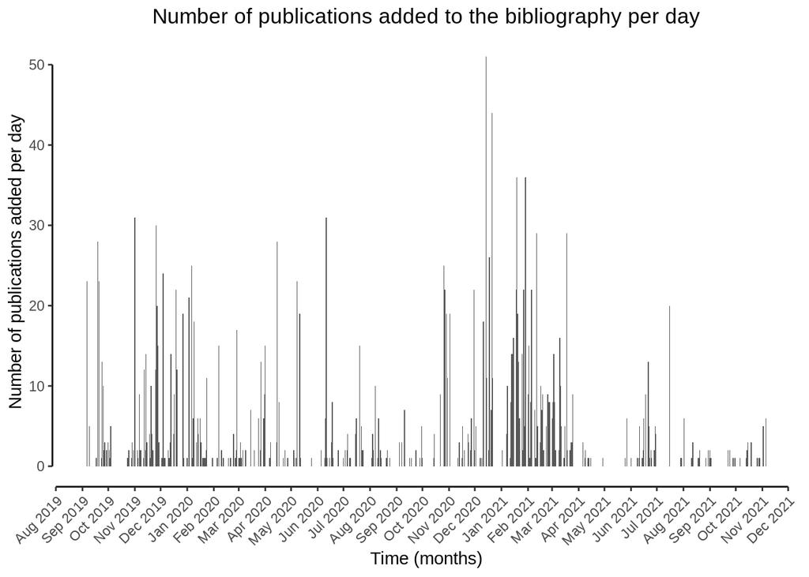

Figure 14: Number of publications added to the bibliography per day (y-axis) over time (in months; x-axis) since creating the bibliography in BibDesk in Sep 2019.

```r
ggplot(data = bib_time, aes(x = date_added_converted, y = num_added)) +
  geom_bar(stat = "identity") +
  ggtitle("Number of publications added to the bibliography per day") +
  ylab("Number of publications added per day") +
  xlab("Time (months)") +
  theme(panel.background = element_blank()) +
  theme(panel.grid.major = element_blank()) +
  theme(panel.grid.minor = element_blank()) +
  theme(axis.line = element_line(colour = "black")) +
  coord_capped_cart(bottom = "both", left = "both") +
  scale_x_date(date_breaks = "1 months", date_labels =  "%b %Y") +
  theme(axis.text.x = element_text(angle = 45, hjust = 1)) +
  theme(plot.title = element_text(hjust = 0.5))
```

```r
  #annotate("segment", x = as.Date("2020-11-01 UTC"),
  #         xend = as.Date("2020-12-01 UTC"), y = 45, yend = 45,
  #         colour = "red", arrow = arrow(length = unit(0.30, "cm"))) +
  #geom_label(aes(x = as.Date("2020-10-01 UTC"), y = 45,
  #      label = "hectic review\nwriting starts"),
  #      color = "red", size = 3, fontface = "bold")
```

# Contact

If a reference is missing, please [create a new issue](https://github.com/lnnrtwttkhn/bibliography/issues/new/choose) and use the issue template for missing publications.

If you have any questions about the bibliography, [the repository](https://github.com/lnnrtwttkhn/bibliography/), if you spotted a bug or would like to make a comment, please also [open an issue](https://github.com/lnnrtwttkhn/bibliography/issues/new) first, or otherwise email Lennart.

Thanks!

# Behind the scenes

The Python script below (`parser.py`) reads the `bibliography.bib` file and uses (1) `bibtexparser` to read the bibliography contents and (2) `pandas` to transform the content into a `bibliography.csv` file that is read into this notebook.

```python
#!/usr/bin/env python3
# -*- coding: utf-8 -*-
import os
import bibtexparser
import pandas as pd
project_name = 'bibliography'
path_options = [os.getenv('PWD'), os.getcwd()]
path_root = [x for x in path_options if project_name in x]
path_root = list(set(path_root))
assert len(path_root) == 1
path_root = path_root[0]
path_code = os.path.join(path_root, 'code')
if not os.path.exists(os.path.join(path_root, 'public')):
    os.makedirs(os.path.join(path_root, 'public'))
with open(os.path.join(path_code, 'bibliography.bib')) as bibtex_file:
    bib_database = bibtexparser.bparser.BibTexParser(
      common_strings=True).parse_file(bibtex_file)
df = pd.DataFrame(bib_database.entries)
df = df.sort_values(by=['author', 'year', 'journal'])
csv_name = "bibliography.csv"
csv_path = os.path.join(path_root, 'public', csv_name)
df.to_csv(csv_path, index=False)
```

The `R Markdown` notebook is then rendered on every push to the repo using continuous integration via Travis:

```bash
dist: bionic
language: r
sudo: true
latex: false
git:
  submodules: false
before_install:
  # install python 3.8
  # see https://docs.python-guide.org/starting/install3/linux/
  - sudo apt-get install software-properties-common
  - sudo add-apt-repository --yes ppa:deadsnakes/ppa
  - sudo apt-get update
  - sudo apt-get install python3.8 python3-pip python3-pandas python3-setuptools
  - pip3 install --upgrade pip
  - pip install -r requirements.txt
  #- sudo apt-get install python3 python3-pip python3-pandas python3-setuptools
  #- pip3 install bibtexparser==1.2.0
  #- pip3 install pyparsing==2.4.7
  #- pip3 install future==0.18.2
# command to run tests
script:
  - make all
cache: packages
r_packages:
  - pacman
  - here
  - data.table
  - DT
  - tidyverse
  - lemon
  - bookdown
  - assertr
deploy:
  # Use Github pages deploy process
  provider: pages
  # Keep builded pages
  skip-cleanup: true
  # Directory where your generated files are located
  local_dir: public
  # Github security/auth token (added in Travis Settings)
  github-token: $GITHUB_TOKEN
  # Incremental commit to keep old build/files from previous deployments
  keep-history: true
  # Git branch on which it should deploy (master, gh-pages, foo...)
  target_branch: gh-pages
  on:
    # Which branch on commit/push will trigger deployment
    branch: master
```

The continuous integration executes a simple `Makefile` that first runs the `parser.py` and then the `bibliography.Rmd` notebook:

```bash
all: bibliography.Rmd

bibliography.Rmd: bibliography.csv
    R -e "rmarkdown::render('code/bibliography.Rmd', output_file = '../public/index.html')"

bibliography.csv:
    python3 code/parser.py
```

The dependencies of the Python code are listed in `requirements.txt`:

```bash
appnope==0.1.0
backcall==0.2.0
bibtexparser==1.2.0
decorator==4.4.2
future==0.18.2
ipykernel==5.3.4
ipython==7.16.1
ipython-genutils==0.2.0
jedi==0.17.2
jupyter-client==6.1.7
jupyter-core==4.7.0
numpy==1.19.4
pandas==1.1.4
parso==0.7.1
pexpect==4.8.0
pickleshare==0.7.5
prompt-toolkit==3.0.8
ptyprocess==0.6.0
Pygments==2.7.4
pyparsing==2.4.7
python-dateutil==2.8.1
pytz==2020.4
pyzmq==20.0.0
six==1.15.0
tornado==6.1
traitlets==4.3.3
wcwidth==0.2.5
```

```r
# set back to old locale
Sys.setlocale("LC_TIME", loc)
```